# Case Study: BellaBeat Fitness Data Analysis

Emma Lacey

2025-06-10

My Google Analytics Certificate  
My Tableau Dashboard

### Data Analysis Process

The case study follows the six-step data analysis process:

- **Ask**
- **Prepare**
- **Process**
- **Analyse**
- **Share**
- **Act**

### Scenario

Since its launch in 2013, Bellabeat has evolved from a promising start-up into a recognised leader in women’s wellness technology. As the company sets its sights on global expansion, it is leveraging the power of user data to unlock new strategic opportunities.

#### Project Goal

- **Analyse** smart device usage data from a key Bellabeat product to uncover how users engage with its wellness technology.
- **Translate** those insights into targeted, data-driven marketing recommendations that directly support strategic decision-making and business growth.
- **Demonstrate** the impact of data analytics in shaping the future of a forward-thinking, wellness-focused brand.

### Step 1. Ask

#### 1.1 Business Task:

**Analyse FitBit Fitness Tracker Data** to gain insights into how consumers are using the FitBit app and discover trends and insights for **Bellabeat marketing strategy**.

#### 1.2 Business Objectives:

1. What are the trends identified?
2. How could these trends apply to Bellabeat customers?
3. How could these trends help influence Bellabeat marketing strategy?

#### 1.3 Deliverables:

1. A clear summary of the business task
2. A description of all data sources used
3. Documentation of any cleaning or manipulation of data
4. A summary of analysis
5. Supporting visualizations and key findings
6. High-level content recommendations based on the analysis

#### 1.4 Key Stakeholders:

1. **Urška Sršen**: Bellabeat’s cofounder and Chief Creative Officer
2. **Sando Mur**: Mathematician, Bellabeat’s cofounder and key member of the Bellabeat executive team
3. **Bellabeat marketing analytics team**: A team of data analysts guiding Bellabeat’s marketing strategy.

### Step 2. Prepare

#### 2.1 Data Source Overview

The dataset used for this analysis is publicly available on Kaggle:  
[FitBit Fitness Tracker Data](https://www.kaggle.com/arashnic/fitbit)

For this analysis, a combination of **11 key CSV files** is selected to enable a more holistic and comprehensive evaluation of user behaviour. These files cover various health and fitness metrics:

Selected CSV Files and Their Content

| Selected.CSV.Files | Content.Description |
| --- | --- |
| dailyActivity_merged.csv | Daily summary: steps, calories, activity intensity |
| dailyCalories_merged.csv | Daily calories burned |
| dailyIntensities_merged.csv | Daily intensity breakdown: sedentary to very active |
| dailySteps_merged.csv | Daily steps taken |
| heartrate_seconds_merged.csv | Second-level heart rate data |
| minuteCaloriesNarrow_merged.csv | Minute-level calorie burn |
| minuteIntensitiesNarrow_merged.csv | Minute-level activity intensity |
| minuteStepsNarrow_merged.csv | Minute-level steps taken |
| sleepDay_merged.csv | Daily sleep duration and efficiency |
| weightLogInfo_merged.csv | Weight, BMI, fat percentage, manual vs. auto-recorded |
| minuteMETsNarrow_merged.csv | Minute-level metabolic equivalents (METs) |

This multi-table approach allows for a richer exploration of how activity, sleep, and heart rate metrics interact across different time resolutions (daily, minute, and second levels).

#### 2.2 ROCCC Data Quality Assessment

Using the ROCCC framework **(Reliable, Original, Comprehensive, Current, and Cited)**, the dataset quality is evaluated as follows:

ROCCC Data Quality Assessment

| ROCCC.Criteria | Evaluation | Details |
| --- | --- | --- |
| Reliable | Low | Only 30 users; some files have fewer records. Varying data completeness and source reliability. |
| Original | Low | Data collected through a third-party platform (Amazon Mechanical Turk). |
| Comprehensive | Medium–High | Multiple dimensions covered (activity, sleep, heart rate, weight). Some missingness, especially in sleep and weight. |
| Current | Low | Data is from 2016; fitness habits, device accuracy, and lifestyle trends have likely changed. |
| Cited | Low | Third-party source with limited transparency on collection methods. |

**Conclusion:** While the data is not optimal for making final business decisions, it provides an excellent sandbox for showcasing data manipulation, integration, and analysis skills.

#### 2.3 Data Limitations and Considerations

- **Small sample size:** While *n* ≈ 30 is statistically acceptable for some analyses, it is not representative of the broader population.
- **User coverage is inconsistent:**
  - Daily activity: 33 unique users
  - Sleep: 24 users
  - Weight: Only 8 users, with 5 manually entered
- **Temporal skew:** Data is clustered mostly between Tuesdays and Thursdays
- **Incomplete tracking:** Not all users recorded all metrics, and some metrics are sparsely populated
- **Outdated data:** Collected in 2016, thus not aligned with current user behavior or Bellabeat’s newer technology
- **Survey-based:** Cannot verify the accuracy or honesty of user tracking and self-entry (especially weight)

#### 2.4 Data Selection Rationale

Rather than relying on a single CSV, this analysis utilizes **11 integrated files** to:

- **Enhance depth:** Combining minute-, daily-, and second-level data allows for multi-resolution insights
- **Showcase ETL and data-wrangling skills:** Merging on Id, timestamps, and dates enables practice with joins, reshaping, and data cleaning
- **Support exploratory and diagnostic analysis:** Useful for hypothesis generation, pattern detection, and visualization
- **Align with Bellabeat’s interest in holistic wellness:** Integrating physical activity, heart rate, sleep, and weight data creates a complete user profile

### Step 3. Process

We are using R to prepare and process the data. To see my SQL version [CLICK HERE](https://github.com/emmalacey14/CapstoneProject)

#### 3.1 Load Required Libraries

The following R packages were used to support data import, transformation, and cleaning:

```r
library(dplyr)       # Data manipulation
library(tidyverse)   # Wrangling and plotting
library(readr)       # Reading CSV files
library(janitor)     # Clean column names
library(lubridate)   # Dates and times
library(hms)         # Time-of-day data
```

#### 3.2 Import Raw Files

All .csv files in the Fitabase Data 4.12.16–5.11.16 folder were loaded into a named list of tibbles for consistency and batch processing.

```r
fitbit_path <- "Fitabase Data 4.12.16-5.11.16"

fitbit_data <- list.files(path = fitbit_path, pattern = "*.csv", full.names = TRUE) %>%
  set_names(~ basename(.) %>% tools::file_path_sans_ext()) %>%
  map(read_csv)

# Optional: Check files were imported
list.files(fitbit_path, pattern = "*.csv")
```

#### 3.3 Standardise Dataset Names

To improve consistency and readability, the datasets were renamed using `snake_case` and stripped of unnecessary suffixes like `_merged`.

```r
# Remove suffix and apply lowercase
names(fitbit_data) <- names(fitbit_data) %>%
  sub("_merged$", "", .) %>%
  tolower()

# Rename for clarity and consistency
rename_map <- c(
  dailyactivity = "daily_activity",
  minutesleep = "minute_sleep",
  sleepday = "sleep_day",
  weightloginfo = "weight_log_info",
  minutecaloriesnarrow = "minute_calories_narrow",
  minuteintensitiesnarrow = "minute_intensities_narrow",
  minutemetsnarrow = "minute_mets_narrow",
  minutestepsnarrow = "minute_steps_narrow",
  hourlycalories = "hourly_calories",
  hourlysteps = "hourly_steps",
  hourlyintensities = "hourly_intensities"
)

# Apply mapping
names(fitbit_data) <- ifelse(names(fitbit_data) %in% names(rename_map),
                             rename_map[names(fitbit_data)],
                             names(fitbit_data))
```

#### 3.4 Remove Redundant Datasets

To avoid duplication and streamline analysis, outdated or overlapping datasets were safely removed:

```r
old_names_to_remove <- c(
  "dailycalories", "dailyintensities", "dailysteps", "dailyactivity",
  "minutesleep", "sleepday", "weightloginfo", "hourlycalories", "hourlysteps"
)

fitbit_data <- fitbit_data[!names(fitbit_data) %in% old_names_to_remove]
```

#### 3.5 Merge Time-Series Data

Separate hourly and minute-level datasets were combined into unified tables by shared keys (`Id`, `ActivityHour`, or `ActivityMinute`).

```r
# Merge hourly data
hourly_activity <- fitbit_data$hourly_calories %>%
  inner_join(fitbit_data$hourly_intensities, by = c("Id", "ActivityHour")) %>%
  inner_join(fitbit_data$hourly_steps, by = c("Id", "ActivityHour"))

# Function to merge multiple narrow datasets
safe_merge <- function(dfs, by_cols) {
  dfs <- keep(dfs, ~ !is.null(.x))
  reduce(dfs, inner_join, by = by_cols)
}

# Merge minute-level narrow data
minute_narrow_dfs <- fitbit_data[c("minute_calories_narrow", "minute_intensities_narrow",
                                   "minute_mets_narrow", "minute_steps_narrow")]

fitbit_data$minute_activity_narrow <- safe_merge(minute_narrow_dfs, by_cols = c("Id", "ActivityMinute"))
```

#### 3.6 Merge Sleep, Daily, and Weight Data

Sleep activity, daily activity, and weight information datasets were combined into a unified table keyed by Id. A full outer join ensures all user records are preserved.

```r
# Merge sleep and daily activity data by Id (full outer join)
combined_data <- merge(sleep_activity, daily_activity, by = "Id", all = TRUE)

# Merge the combined data with weight information (full outer join)
combined_data <- merge(combined_data, weight_info, by = "Id", all = TRUE)

# Check number of unique users after merging
n_distinct(combined_data$Id)
```

#### 3.7 Clean Columns and Remove Duplicates

All column names were standardsed and duplicate rows removed across the entire dataset collection.

```r
# Clean column names across all datasets
fitbit_data <- lapply(fitbit_data, janitor::clean_names)

# Remove duplicates
fitbit_data <- lapply(fitbit_data, function(df) {
  df[!duplicated(df), ]
})

# Also apply to merged datasets
hourly_activity <- hourly_activity %>% distinct()
fitbit_data$minute_activity_narrow <- fitbit_data$minute_activity_narrow %>% distinct()
combined_data <-combined_data %>% distinct()
```

A final check ensures all datasets were correctly renamed and retained for further exploration.

### Step 4. Analyse

I am using R again to do my analysis, to see my SQL versions [CLICK HERE](https://github.com/emmalacey14/CapstoneProject)

#### 4.1 Data summary

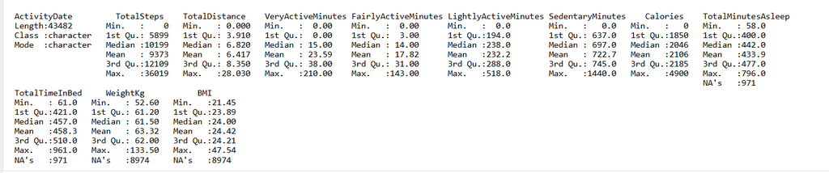

```r
combined_data %>%
  dplyr::select(
    ActivityDate,
    TotalSteps,
    TotalDistance,
    VeryActiveMinutes,
    FairlyActiveMinutes,
    LightlyActiveMinutes,
    SedentaryMinutes,
    Calories,
    TotalMinutesAsleep,
    TotalTimeInBed,
    WeightKg,
    BMI
  ) %>%
  summary()
```

#### 4.2 Activity breakdown

Percentage of active minutes in the four categories: very active, fairly active, lightly active and sedentary. From the pie chart, we can see that most users spent 72.5% of their daily activity in sedentary minutes and only 2.37% in very active minutes.

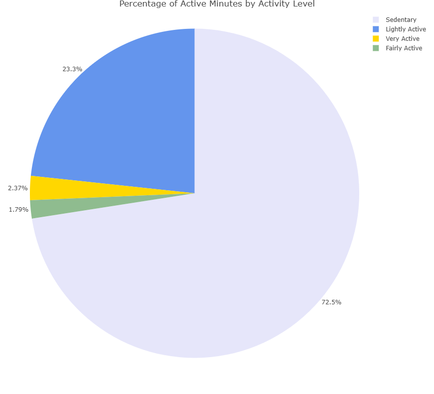

```r
library(dplyr)
library(tidyr)
library(plotly)

activity_summary <- combined_data %>%
  summarise(across(c(VeryActiveMinutes, FairlyActiveMinutes, LightlyActiveMinutes, SedentaryMinutes),
                   ~sum(.x, na.rm = TRUE))) %>%
  pivot_longer(everything(), names_to = "ActivityLevel", values_to = "Minutes") %>%
  mutate(
    TotalMinutes = sum(Minutes),
    Percentage = (Minutes / TotalMinutes) * 100,
    ActivityLevel = recode(ActivityLevel,
                           "VeryActiveMinutes" = "Very Active",
                           "FairlyActiveMinutes" = "Fairly Active",
                           "LightlyActiveMinutes" = "Lightly Active",
                           "SedentaryMinutes" = "Sedentary"))

plot_ly(
  data = activity_summary,
  labels = ~ActivityLevel,
  values = ~Percentage,
  type = 'pie',
  textposition = 'outside',
  textinfo = 'percent',
  marker = list(colors = c("gold", "darkseagreen", "cornflowerblue", "lavender"))
) %>%
  layout(
    title = 'Percentage of Active Minutes by Activity Level',
    showlegend = TRUE
  )
```

#### 4.3 Weekly Overview

The bar graph shows that there is a jump on Saturday: user spent LESS time in sedentary minutes and are MORE active.

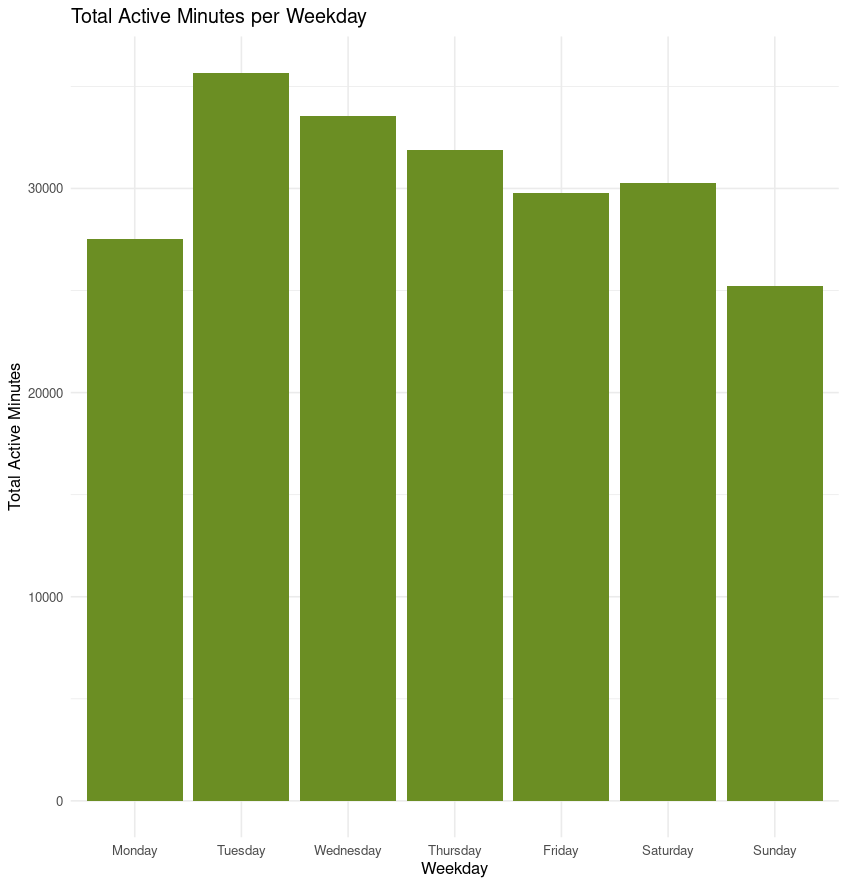

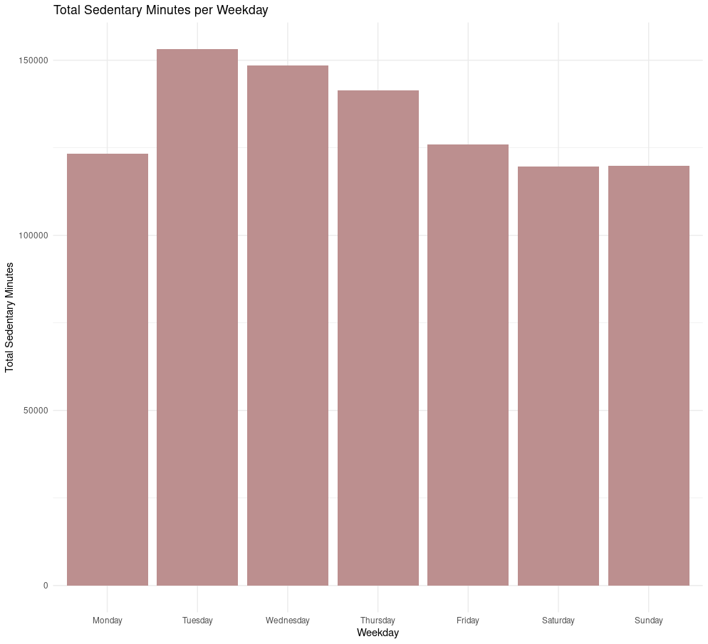

This can be broken down further to show what active type they are engaging in.

```r
# Summarise active minutes by weekday and activity type for whole week
active_breakdown_week <- daily_activity %>%
  group_by(Weekday) %>%
  summarise(
    VeryActive = sum(VeryActiveMinutes, na.rm = TRUE),
    FairlyActive = sum(FairlyActiveMinutes, na.rm = TRUE),
    LightlyActive = sum(LightlyActiveMinutes, na.rm = TRUE)
  ) %>%
  pivot_longer(cols = -Weekday, names_to = "ActivityLevel", values_to = "Minutes")

# Ensure weekdays are ordered correctly
weekday_order <- c("Monday", "Tuesday", "Wednesday", "Thursday", "Friday", "Saturday", "Sunday")
active_breakdown_week$Weekday <- factor(active_breakdown_week$Weekday, levels = weekday_order)
```

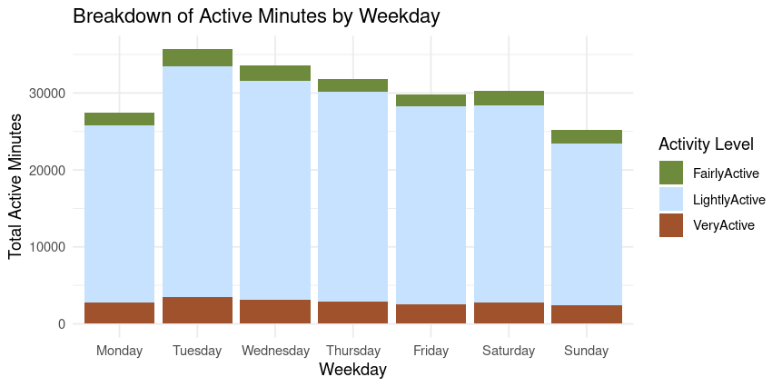

#### 4.4 Steps Overview

Looking at ‘Total Steps’ we can see when users are most active. From 5PM to 7PM the users take the most steps.

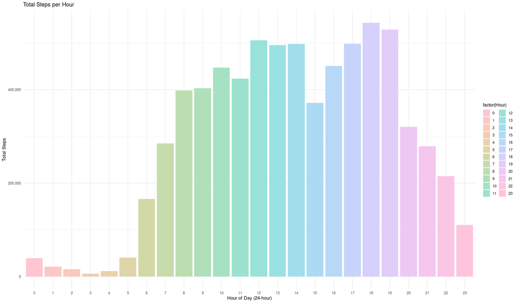

```r
ggplot(steps_by_hour, aes(x = factor(Hour), y = TotalSteps, fill = factor(Hour))) +
  geom_bar(stat = "identity") +
  scale_fill_discrete_qualitative(palette = "Pastel 1", n = length(unique(steps_by_hour$Hour))) +
  scale_y_continuous(labels = comma) +  # <- this disables scientific notation
  labs(title = "Total Steps per Hour",
       x = "Hour of Day (24-hour)",
       y = "Total Steps") +
  theme_minimal()
```

Or our data can be presented in a line chart:

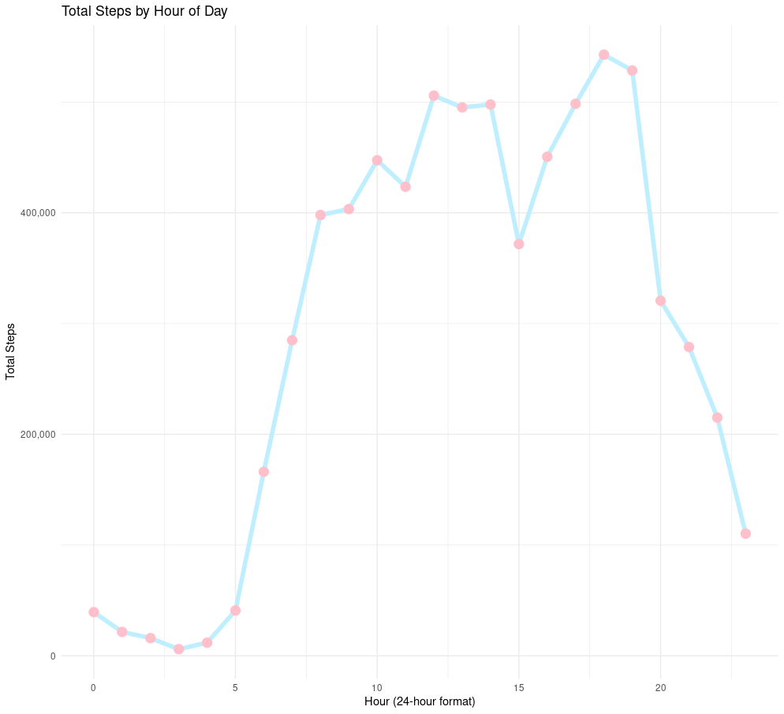

```r
library(ggplot2)

ggplot(steps_by_hour, aes(x = Hour, y = TotalSteps)) +
  geom_line(color = "lightblue1",size = 2) +
  geom_point(color = "pink", size=4) +
  scale_y_continuous(labels = scales::comma_format()) +
  labs(title = "Total Steps by Hour of Day",
       x = "Hour (24-hour format)",
       y = "Total Steps") +
  theme_minimal()
```

Lets look at step count per day. Users take the most steps on Tuesdays, the amount of steps taken slowly decreases throughout the week and then spikes again on Saturdays.

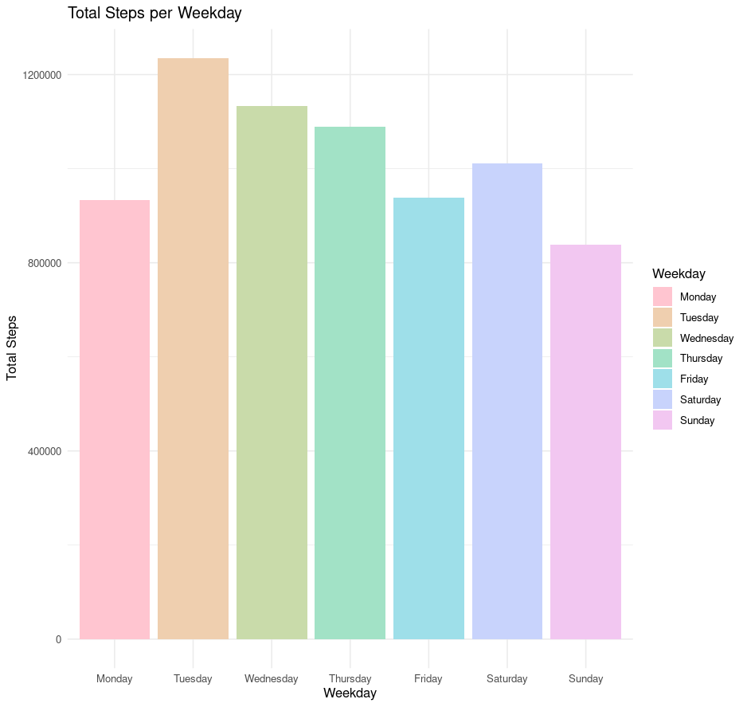

We can also look at how many steps are been taken during each activity type.

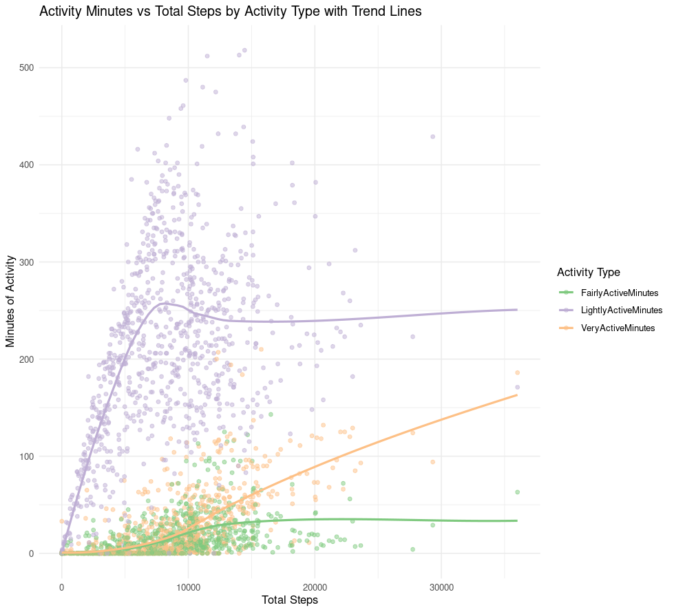

```r
ggplot(long_activity_active, aes(x = TotalSteps, y = Minutes, color = ActivityType)) +
  geom_point(alpha = 0.5) +
  geom_smooth(method = "loess", se = FALSE) +  # trend line only, no confidence interval
  labs(
    title = "Activity Minutes vs Total Steps by Activity Type with Trend Lines",
    x = "Total Steps",
    y = "Minutes of Activity",
    color = "Activity Type"
  ) +
  theme_minimal() +
  scale_color_brewer(palette = "Accent")
```

This shows us that most steps are being taken during the ‘light’ activity type.

#### 4.5 Burning Calories

Lets look at the relationship between activity vs calories.

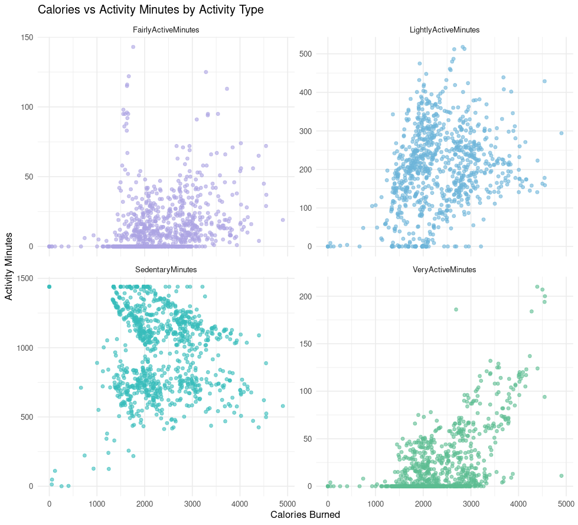

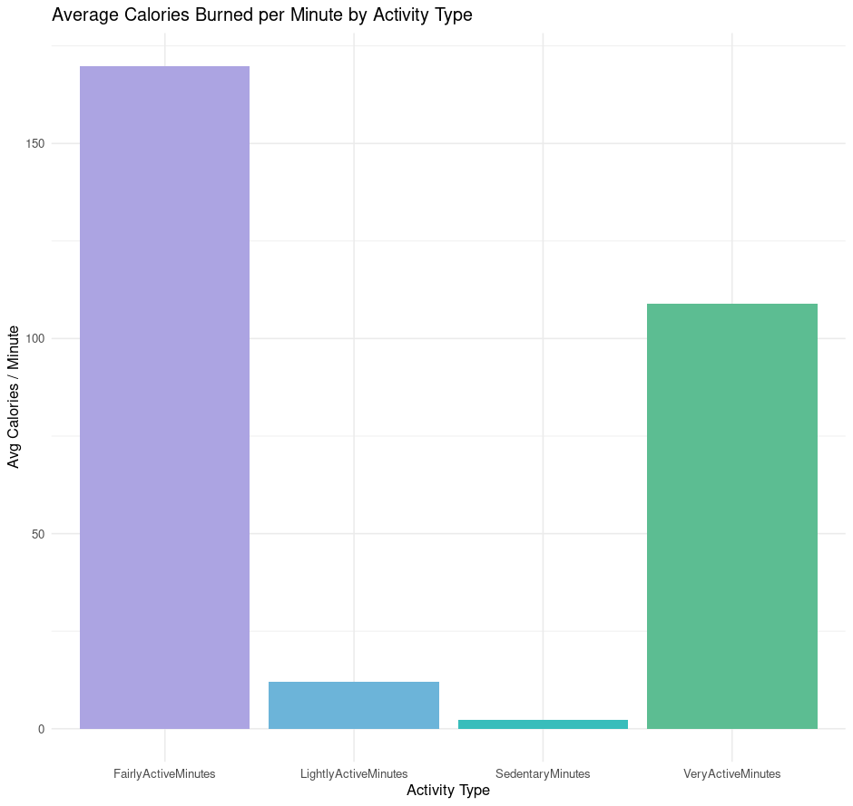

On average, those in a ‘fairly active’ or ‘very active’ phase burn more calories per minute than those in ‘lightly active’ or ‘sedentary’ phase.

Lets see if there is any correlation between sleep and calories - does increased sleep mean burning less calories?

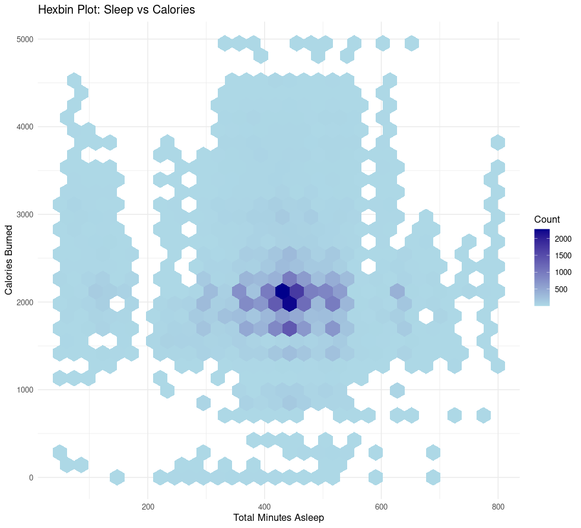

```r
ggplot(combined_data, aes(x = TotalMinutesAsleep, y = Calories)) +
  stat_binhex(bins = 30) +
  scale_fill_gradient(low = "lightblue", high = "darkblue") +
  labs(
    title = "Hexbin Plot: Sleep vs Calories",
    x = "Total Minutes Asleep",
    y = "Calories Burned",
    fill = "Count"
  ) +
  theme_minimal()
```

The chart doesn’t show us much, so lets check with a correlation test:

```r
cor_test <- cor.test(combined_data$TotalMinutesAsleep, combined_data$Calories, use = "complete.obs")
cor_test$estimate  # Shows Pearson correlation

-0.01769069
```

The number is very close to 0, so there’s almost no linear correlation.

#### 4.6 Sleep

According to the article: [Fitbit Sleep Study](https://store.google.com/intl/en/ideas/articles/sleep-study/), 55 minutes are spent awake in bed before going to sleep. We have 13 users in our dataset who spent over 55 minutes awake before going to sleep.

```r
awake_55_any_day <- sleepDay_merged %>%
  mutate(AwakeTime = TotalTimeInBed - TotalMinutesAsleep) %>%
  filter(AwakeTime >= 55) %>%
  distinct(Id)

nrow(awake_55_any_day)
```

[output not shown]

Using our data, we found that the average user is spending 39 minutes awake before going to sleep. We have 16 users in our dataset spening over 39 minutes awake before going to sleep.

```r
average_awake_time <- sleepDay_merged %>%
  mutate(AwakeTime = TotalTimeInBed - TotalMinutesAsleep) %>%
  summarise(AvgAwakeTime = mean(AwakeTime, na.rm = TRUE)) %>%
  pull(AvgAwakeTime)

cat("Average time spent awake in bed before sleep (minutes):", round(average_awake_time, 2), "\n")
```

[output not shown]

```r
awake_39_any_day <- sleepDay_merged %>%
  mutate(AwakeTime = TotalTimeInBed - TotalMinutesAsleep) %>%
  filter(AwakeTime >= 39) %>%
  distinct(Id)

nrow(awake_39_any_day)
```

[output not shown]

### Step 6. Act

Based on the analysis of user activity data, several clear trends and opportunities for improving user engagement and health outcomes have emerged. Below are actionable recommendations Bellabeat can implement:

#### ✅ Actionable Recommendations

##### 🔔 Step Goal Notifications

- Send real-time reminders of remaining steps around **5–7 PM** to help users hit 10,000-step targets.
- Send motivational prompts **Thursday evening and Friday/Saturday mornings** to boost end-of-week activity.

##### 💪 Workout Suggestions Based on Intensity

- Recommend short, tailored workouts based on current activity level (e.g., 10-min moderate session if still sedentary).
- Suggest higher-intensity activities for users lacking vigorous movement.

##### 🎁 Incentive-Based Reward System

- Offer **credits or unlockable content** (e.g., premium workouts) for hitting daily/weekly goals.
- Replace or supplement badges with **tangible rewards** to improve long-term motivation.

##### ⚖️ Improve Data Collection with Automated Tools

- Market smart devices (e.g., **Bluetooth-enabled scales**) to capture weight automatically.
- Consider phasing out or deemphasizing underused manual entry features like distance logging.

##### 📆 Weekend-Focused Activity Campaigns

- Launch a **“Weekend Recharge”** initiative promoting longer, enjoyable activities on Sundays.
- Provide insights on how even light movement combats sedentary behavior.

##### 📈 Expand Data Sources for Future Analysis

- Incorporate data from additional fitness trackers to explore longitudinal user behavior.
- This would help personalise recommendations and validate patterns over time.

##### 😴 Encourage Better Sleep Habits

- Use devices to detect extended awake periods and prompt users with bedtime reminders.
- Educate users on **sleep quality vs. quantity** to support holistic wellness.